# Assignment 5

Louis Wang

2022-10-26

# 1. Conditional probability, Bayes rule and independence

## 1.1 (Q1)

$P(B|A^c)=1-P(B^c|A^c)=1-0.75=0.25$  
$P(B)=P(B|A)P(A)+P(B|A^c)P(A^c)=0.8*0.9+0.25*0.1=0.745$ $P(A|B)=\frac{P(B|A)P(A)}{P(B)}=\frac{0.8*0.9}{0.745}=0.96644295$

## 1.2 (Q1)

1. $P(A|B)=\frac{P(A)}{P(B)}; when\ P(B\backslash A)=0,\ P(A|B)=1$
2. $PA|B)=0;\ P(A|B)=0$
3. $P(A|B)=\frac{P(A \bigcap B)}{P(B)}=\frac{P(B)}{P(B)}=1;\ P(A|B)=1$
4. $P(A|\Omega)=\frac{P(A \bigcap \Omega)}{P(\Omega)}=\frac{P(A)}{P(\Omega)}=P(A)$
5. $P(A \bigcap B \bigcap C)=P(A|(B \bigcap C))P(B \bigcap C)=P(A|(B \bigcap C))P(B|C)P(C)$
6. $P(A|B \bigcap C)=\frac{P(A \bigcap B \bigcap C)}{P(B \bigcap C)}=\frac{P(B|(A \bigcap C))P(A|C)P(C)}{P(B|C)P(C)}=\frac{P(B|(A \bigcap C))P(A|C)}{P(B|C)}$

## 1.2 (Q2)

Suppose A = windy, B = the flight being cancelled, so $P(B|A)=0.3,\ P(B|A^c)=0.1,\ P(A)=0.2$  
$P(B^c)=1-P(B)=1-(P(B \bigcap A)+P(B \bigcap A^c))=1-(P(B|A)P(A)+P(B|A^c)P(A^c))=1-(0.3*0.2+0.1*0.8)=0.86$

## 1.3 (Q1)

$P(A \bigcap B \bigcap C)=P(\emptyset)=0\neq P(A)P(B)P(C)$ so, events A,B,C are not mutually independent

## 1.4 (Q1)

$P(B1\bigcap C2)=\frac{1}{3}(\frac{1}{3}*\frac{1}{2} + \frac{1}{3})=\frac{1}{6}$  
$P(A3|B1\bigcap C2)=\frac{P(A3\bigcap B1\bigcap C2)}{P(B1\bigcap C2)}=\frac{2}{3}$  
Since the possibility of initially choose a goat is 2/3, so the possibility of winning a car if we switch the choice is 2/3, while the possibility of we don’t switch the choice is 1/3, which means if we change our initial choice, the chance of winning a car is higher than we don’t change. ….

# 2. Random variables and discrete random variables

## 2.1 (Q1)

When X and Y are independent, E(XY)=E(X)E(Y). So $COV(X,Y)=E[(X-E(X)(Y-E(Y)))]=E(XY)-E(X)(Y)=0$

## 2.2 (Q1)

1. $$p_x(X)=\begin{cases}
   1-\alpha-\beta, & X=0\\
   \alpha, & X=3\\
   \beta, & X=10\\
   0, & other\ values\\
   \end{cases}$$
2. $E(X)=3\alpha+10\beta$
3. $Var(X)=9\alpha+100\beta-9\alpha^2-60\alpha\beta-100\beta^2$
4. $SD(X)=\sqrt{9\alpha+100\beta-9\alpha^2-60\alpha\beta-100\beta^2}$

## 2.2 (Q2)

1. $P_X(X)=(1-\alpha-\beta)1_S(0)+\alpha1_S(3)+\beta1_S(10)$
2. $$F_X(X)=\begin{cases}
   0 & X<0\\
   1-\alpha-\beta & 0\leq X<3\\
   1-\beta & 3\leq X<10\\
   1 & X\geq 10\\
   \end{cases}$$

## 2.2 (Q4)

Define a new random variance Y = X1 + X2 + · · · + Xn where X1, X2, · · · , Xn are independent random variables, each of which has the same distribution as the random variable X.

### step1

```r
# Let n = 3 and generate 50000 samples of {X1, X2, X3} using the rmultinom() function. Store the samples in an object called samples_Xi.
# Then based on samples_Xi, create 50000 samples of Y and store it in a data-frame called samples_Y, consisting of a single column called Y.
samples_Xi <- rmultinom(50000, 3, c(0.5, 0.2, 0.3) )
samples_Y = data.frame(Y=0*samples_Xi[1,] + 3*samples_Xi[2,] + 10*samples_Xi[3,])
```

### step2

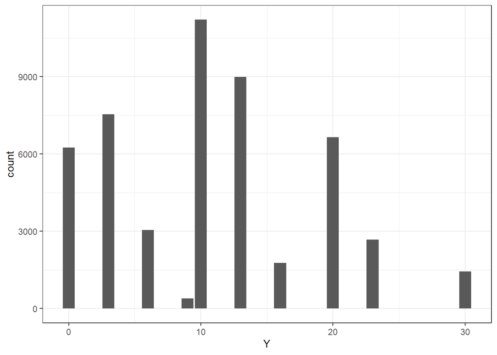

```r
# Use the ggplot and geom_bar() function to create a bar plot for the samples of Y .
ggplot(samples_Y, aes(Y)) + geom_bar() + theme_bw()
```